# week3-2 Assignment - Chi-Square Test

Haruna Aremu

06-04-2026

This analysis applies chi-square goodness-of-fit tests to evaluate whether molecular markers in two populations — mouse and maize — conform to their expected Mendelian segregation ratios. The mouse dataset contains marker genotype data for progeny derived from a backcross population, where each marker is expected to segregate in a 1:1 ratio. The maize dataset contains marker genotype data for an F2 population derived from divergent parents, where markers are expected to follow a 1:2:1 ratio. Markers that significantly deviate from these expectations are considered to show segregation distortion.

# Loading of Data

The datasets are loaded from CSV files and previewed using the `head()` function to confirm their structure before analysis.

```r
mouse_data <- read.csv("data/mouse.csv")

head(mouse_data)
```

```
##    Ind M1 M2 M3 M4 M5 M6 M7 M8 M9 M10 M11 M12 M13 M14 BW
## 1 Ind1  1  1  1  1  1  1  1  1  1   1   1   1   1   1 50
## 2 Ind2  1  1  1  1  1  1  1  1  1   1   1   1   1   0 54
## 3 Ind3  0  1  1  1  1  1  1  1  1   1   1   1   1   1 49
## 4 Ind4  0  0  0  0  0  0  0  0  0   0   0   0   0   0 41
## 5 Ind5  1  1  1  1  1  1  1  1  1   1   1   1   1   1 36
## 6 Ind6  0  0  0  0  0  0  0  0  0   0   0   0   0   0 48
```

```r
maize_data <- read.csv("data/maize.csv")

head(maize_data)
```

```
##   IND M1 M2 M3 M4 M5 M6 M7 M8 M9 M10 M11 M12   GY
## 1   1  2  1  0  0  0  0  0  1  1   1   0   0 6.25
## 2   2  1  1  1  1  1  2  2  2  2   0   0   1 3.00
## 3   3  1  2  2  2  2  1  1  1  1   2   2   2 3.00
## 4   4  1  0  0  0  0  0  0  0  0   1   2   2 4.00
## 5   5  0  0  1  1  1  1  1  1  1   1   1   1 3.00
## 6   6  1  0  0  0  0  1  1  1  1   0   0   0 3.75
```

# Performing Chi-square Test

## Mouse Data

For a backcross population, each marker is expected to segregate in a **1:1 ratio** between the two parental allele classes. A chi-square goodness-of-fit test is applied to each marker to determine whether the observed genotype counts deviate significantly from this expectation. P-values are stored for all 14 markers and plotted in ascending order against the conventional significance threshold of α = 0.05.

```r
# For mouse data, the expected ratio is 1:1

exp <- c(0.5, 0.5)
p_value <- c()

M <- ncol(mouse_data[, 2: 15])

for (m in 2: 15) {
  obs <- table(mouse_data[ , m])

  chi_test <- chisq.test(x = obs, p = exp)

  p_value[m -1] <- chi_test$p.value

}
```

The sorted p-values are plotted below. Markers falling below the red line (α = 0.05) show statistically significant deviation from the expected 1:1 segregation ratio

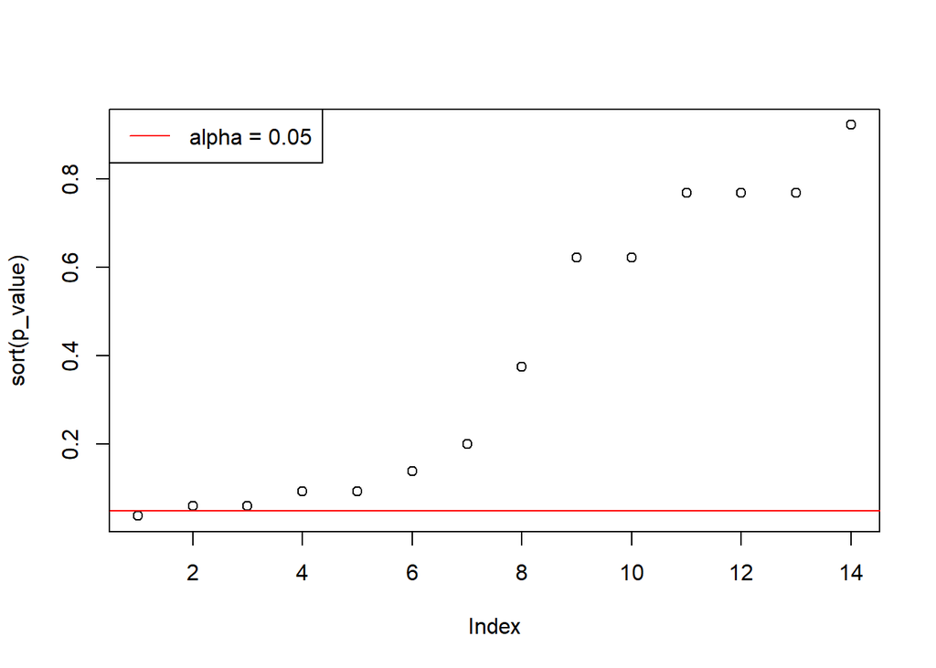

```r
plot(sort(p_value))
abline(h = 0.05, col = "red")
legend("topleft", legend=c("alpha = 0.05"), col=c("red"), lty=1)
```

A frequency table is used to count how many markers fall below the significance threshold, indicating segregation distortion.

```r
table(p_value < 0.05)
```

```
##
## FALSE  TRUE
##    13     1
```

Only 1 marker shows significant deviation from the expected 1:1 segregation ratio at α = 0.05, suggesting that the vast majority of markers in this backcross population are segregating normally.

## Bonferroni Correction

When testing multiple markers simultaneously, the probability of obtaining at least one false positive increases with the number of tests performed. The Bonferroni correction addresses this multiple testing problem by adjusting the significance threshold to α/M, where M is the total number of markers tested. This is a conservative approach that controls the family-wise error rate.

```r
table(p_value < 0.05/M)
```

```
##
## FALSE
##    14
```

The plot below overlays both the uncorrected (α = 0.05, red) and Bonferroni-corrected (α/M, blue) thresholds, allowing a visual comparison of which markers remain significant after the correction is applied.

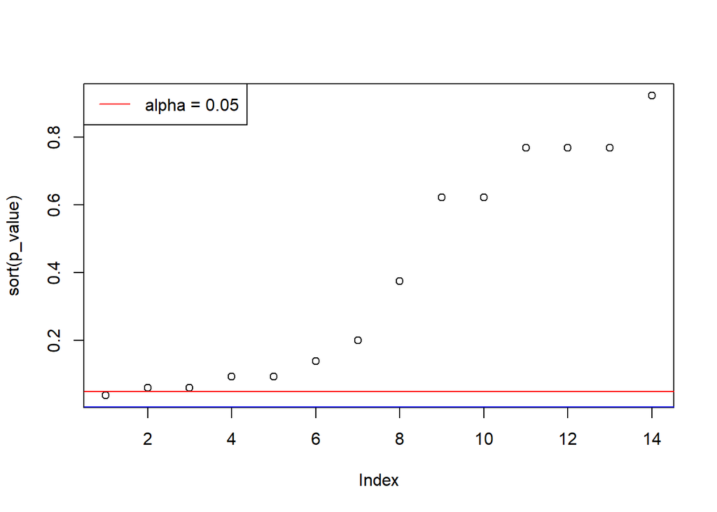

```r
plot(sort(p_value))
abline(h = c(0.05, 0.05/M), col = c("red", "blue"))
legend("topleft", legend=c("alpha = 0.05"), col=c("red"), lty=1)
```

## Maize Data

For an F2 population, heterozygous parents are expected to produce offspring in a **1:2:1 ratio** (homozygous reference : heterozygous : homozygous alternate), consistent with Mendelian segregation at a single locus. Chi-square goodness-of-fit tests are applied across all 12 markers, and p-values are plotted against the α = 0.05 threshold.

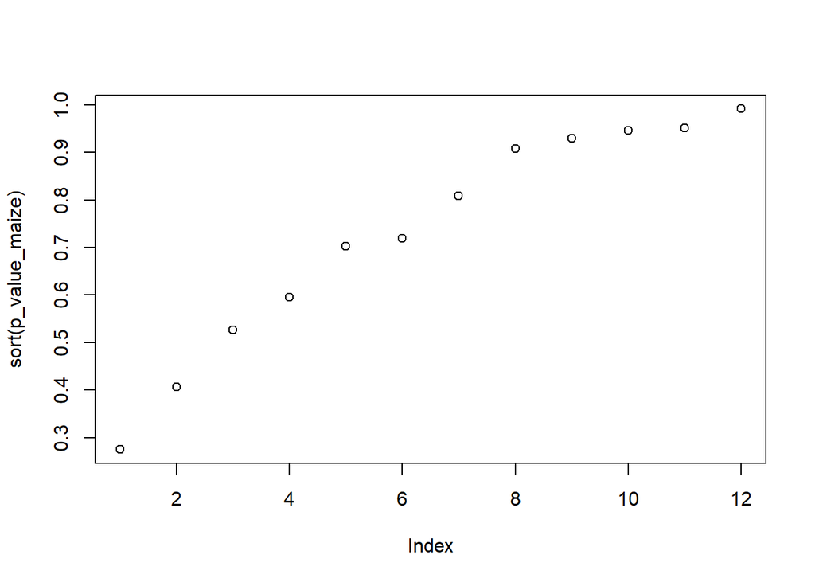

```r
exp_maize <- c(0.25, 0.5, 0.25)
p_value_maize <- c()
M_maize <- ncol(maize_data[, 2:13])

for(m in 2:13){
  obs <- table(maize_data[, m])
  chi_test <- chisq.test(x = obs, p = exp_maize)
  p_value_maize[m - 1] <- chi_test$p.value
}

plot(sort(p_value_maize))
abline(h = 0.05, col = "red")
```

A frequency table is used to count how many markers fall below the significance threshold, indicating segregation distortion

```r
table(p_value_maize < 0.05)
```

```
##
## FALSE
##    12
```

Here all 12 markers in the maize F2 population have p-values exceeding the 0.05 significance threshold, indicating that none deviate significantly from the expected 1:2:1 segregation ratio. Since no evidence of segregation distortion is detected, applying a Bonferroni correction is unnecessary in this case.